# INTRODUCTION:

```
Cardiovascular diseases are the leading cause of death globally.
To identify the causes and to develop a system to predict heart attack in an effective manner is necessary.
The presented data has all the information about all the relevant factors that might have an impact on heart health.
```

variable description :

### 1.Perform preliminary data inspection and report the findings as the structure of the data, missing values, duplicates, etc.

```python
# Importing all neccessary libraries/packages
import pandas as pd
import numpy as np
import matplotlib.pyplot as plt
import seaborn as sns
```

```python
# Loading Data
heartdata=pd.read_excel("data.xlsx",sheet_name='heart')
```

```python
heartdata.head()
```

|  | age | sex | cp | trestbps | chol | fbs | restecg | thalach | exang | oldpeak | slope | ca | thal | target |
| --- | --- | --- | --- | --- | --- | --- | --- | --- | --- | --- | --- | --- | --- | --- |
| 0 | 63 | 1 | 3 | 145 | 233 | 1 | 0 | 150 | 0 | 2.3 | 0 | 0 | 1 | 1 |
| 1 | 37 | 1 | 2 | 130 | 250 | 0 | 1 | 187 | 0 | 3.5 | 0 | 0 | 2 | 1 |
| 2 | 41 | 0 | 1 | 130 | 204 | 0 | 0 | 172 | 0 | 1.4 | 2 | 0 | 2 | 1 |
| 3 | 56 | 1 | 1 | 120 | 236 | 0 | 1 | 178 | 0 | 0.8 | 2 | 0 | 2 | 1 |
| 4 | 57 | 0 | 0 | 120 | 354 | 0 | 1 | 163 | 1 | 0.6 | 2 | 0 | 2 | 1 |

```python
heartdata.info() #To get the entire information about the null values and the data types of the features.
```

```
<class 'pandas.core.frame.DataFrame'>
RangeIndex: 303 entries, 0 to 302
Data columns (total 14 columns):
 #   Column    Non-Null Count  Dtype
---  ------    --------------  -----
 0   age       303 non-null    int64
 1   sex       303 non-null    int64
 2   cp        303 non-null    int64
 3   trestbps  303 non-null    int64
 4   chol      303 non-null    int64
 5   fbs       303 non-null    int64
 6   restecg   303 non-null    int64
 7   thalach   303 non-null    int64
 8   exang     303 non-null    int64
 9   oldpeak   303 non-null    float64
 10  slope     303 non-null    int64
 11  ca        303 non-null    int64
 12  thal      303 non-null    int64
 13  target    303 non-null    int64
dtypes: float64(1), int64(13)
memory usage: 33.3 KB
```

```python
heartdata.shape # To know thw structure
```

```
(303, 14)
```

```python
heartdata.isna().sum() # To ckeck null values/missing values
```

```
age         0
sex         0
cp          0
trestbps    0
chol        0
fbs         0
restecg     0
thalach     0
exang       0
oldpeak     0
slope       0
ca          0
thal        0
target      0
dtype: int64
```

```python
heartdata.duplicated()
```

```
0      False
1      False
2      False
3      False
4      False
       ...
298    False
299    False
300    False
301    False
302    False
Length: 303, dtype: bool
```

2.Based on the findings from the previous question, remove duplicates (if any) and treat missing values using an appropriate strategy.

Though the dataset doesn't have any missing value or duplicated value, we dont have to do any further stratergy

1. Get a preliminary statistical summary of the data. Explore the measures of central tendencies and the spread of the data overall.

```python
heartdata.describe()  #statistical summary of data
```

|  | age | sex | cp | trestbps | chol | fbs | restecg | thalach | exang | oldpeak | slope | ca | thal | target |
| --- | --- | --- | --- | --- | --- | --- | --- | --- | --- | --- | --- | --- | --- | --- |
| count | 303.000000 | 303.000000 | 303.000000 | 303.000000 | 303.000000 | 303.000000 | 303.000000 | 303.000000 | 303.000000 | 303.000000 | 303.000000 | 303.000000 | 303.000000 | 303.000000 |
| mean | 54.366337 | 0.683168 | 0.966997 | 131.623762 | 246.264026 | 0.148515 | 0.528053 | 149.646865 | 0.326733 | 1.039604 | 1.399340 | 0.729373 | 2.313531 | 0.544554 |
| std | 9.082101 | 0.466011 | 1.032052 | 17.538143 | 51.830751 | 0.356198 | 0.525860 | 22.905161 | 0.469794 | 1.161075 | 0.616226 | 1.022606 | 0.612277 | 0.498835 |
| min | 29.000000 | 0.000000 | 0.000000 | 94.000000 | 126.000000 | 0.000000 | 0.000000 | 71.000000 | 0.000000 | 0.000000 | 0.000000 | 0.000000 | 0.000000 | 0.000000 |
| 25% | 47.500000 | 0.000000 | 0.000000 | 120.000000 | 211.000000 | 0.000000 | 0.000000 | 133.500000 | 0.000000 | 0.000000 | 1.000000 | 0.000000 | 2.000000 | 0.000000 |
| 50% | 55.000000 | 1.000000 | 1.000000 | 130.000000 | 240.000000 | 0.000000 | 1.000000 | 153.000000 | 0.000000 | 0.800000 | 1.000000 | 0.000000 | 2.000000 | 1.000000 |
| 75% | 61.000000 | 1.000000 | 2.000000 | 140.000000 | 274.500000 | 0.000000 | 1.000000 | 166.000000 | 1.000000 | 1.600000 | 2.000000 | 1.000000 | 3.000000 | 1.000000 |
| max | 77.000000 | 1.000000 | 3.000000 | 200.000000 | 564.000000 | 1.000000 | 2.000000 | 202.000000 | 1.000000 | 6.200000 | 2.000000 | 4.000000 | 3.000000 | 1.000000 |

```
array([[<AxesSubplot:title={'center':'age'}>,
        <AxesSubplot:title={'center':'sex'}>,
        <AxesSubplot:title={'center':'cp'}>,
        <AxesSubplot:title={'center':'trestbps'}>],
       [<AxesSubplot:title={'center':'chol'}>,
        <AxesSubplot:title={'center':'fbs'}>,
        <AxesSubplot:title={'center':'restecg'}>,
        <AxesSubplot:title={'center':'thalach'}>],
       [<AxesSubplot:title={'center':'exang'}>,
        <AxesSubplot:title={'center':'oldpeak'}>,
        <AxesSubplot:title={'center':'slope'}>,
        <AxesSubplot:title={'center':'ca'}>],
       [<AxesSubplot:title={'center':'thal'}>,
        <AxesSubplot:title={'center':'target'}>, <AxesSubplot:>,
        <AxesSubplot:>]], dtype=object)
```

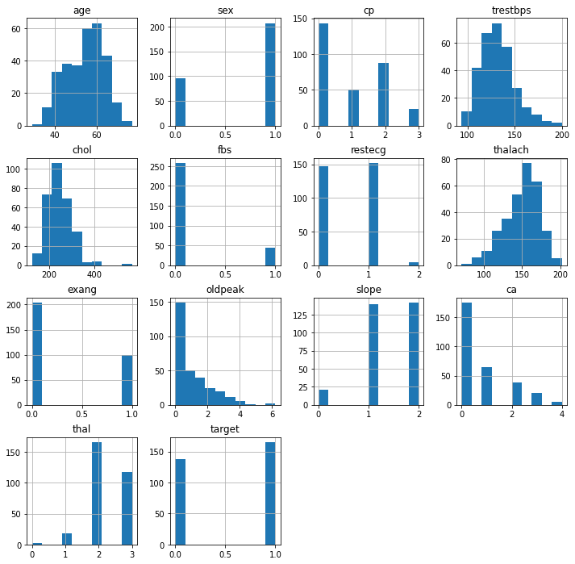

```python
heartdata.hist(figsize=(12,12), layout=(4,4))
```

with Histograms we can see the shape of each/spread of the data and provides the count of number of observations in each bin

```python
heartdata.skew()
```

```
age        -0.202463
sex        -0.791335
cp          0.484732
trestbps    0.713768
chol        1.143401
fbs         1.986652
restecg     0.162522
thalach    -0.537410
exang       0.742532
oldpeak     1.269720
slope      -0.508316
ca          1.310422
thal       -0.476722
target     -0.179821
dtype: float64
```

1. Identify the data variables which might be categorical in nature. Describe and explore these variables using appropriate tools. For example: count plot.

```python
heartdata.info()
```

```
<class 'pandas.core.frame.DataFrame'>
RangeIndex: 303 entries, 0 to 302
Data columns (total 14 columns):
 #   Column    Non-Null Count  Dtype
---  ------    --------------  -----
 0   age       303 non-null    int64
 1   sex       303 non-null    int64
 2   cp        303 non-null    int64
 3   trestbps  303 non-null    int64
 4   chol      303 non-null    int64
 5   fbs       303 non-null    int64
 6   restecg   303 non-null    int64
 7   thalach   303 non-null    int64
 8   exang     303 non-null    int64
 9   oldpeak   303 non-null    float64
 10  slope     303 non-null    int64
 11  ca        303 non-null    int64
 12  thal      303 non-null    int64
 13  target    303 non-null    int64
dtypes: float64(1), int64(13)
memory usage: 33.3 KB
```

```python
# though here there is no object data type, I manually detect the categorical variables
cat_var=[]
cont_var=[]
for var in heartdata.columns:
    if heartdata[var].nunique() <= 6:
        cat_var.append(var)
    else:
        cont_var.append(var)
```

```python
print("categrical variable in dataset:", cat_var)
print("continous variable in dataset:", cont_var)
```

```
categrical variable in dataset: ['sex', 'cp', 'fbs', 'restecg', 'exang', 'slope', 'ca', 'thal', 'target']
continous variable in dataset: ['age', 'trestbps', 'chol', 'thalach', 'oldpeak']
```

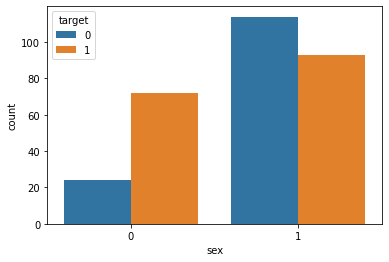

```python
sns.countplot(x='sex',hue='target',data=heartdata)
```

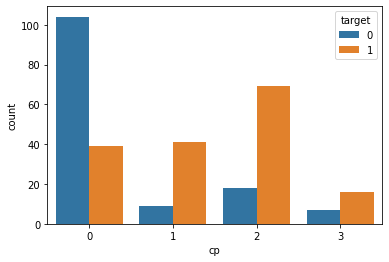

```python
# cp : chest pain type
#        -- Value 0: typical angina
#        -- Value 1: atypical angina
#        -- Value 2: non-anginal pain
#        -- Value 3: asymptomatic
sns.countplot(x='cp',hue='target',data=heartdata)
```

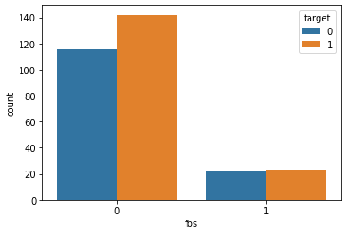

```python
# fbs: fasting blood sugar, 0:false, 1:true
sns.countplot(x='fbs',hue='target',data=heartdata)
```

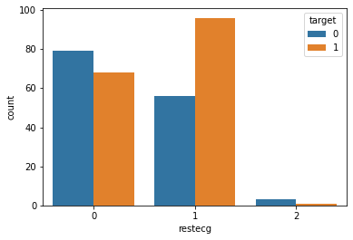

```python
# restecg : resting electrocardiographic results
# 	-- Value 0: normal
#   -- Value 1: having ST-T wave abnormality
#   -- Value 2: showing probable or definite left ventricular hypertrophy

sns.countplot(x='restecg',hue='target',data=heartdata)
```

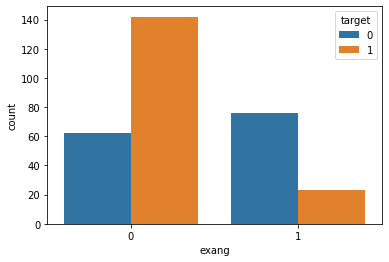

```python
# exang   : excercise induced angina (1: yes, 0: no)
sns.countplot(x='exang',hue='target',data=heartdata)
```

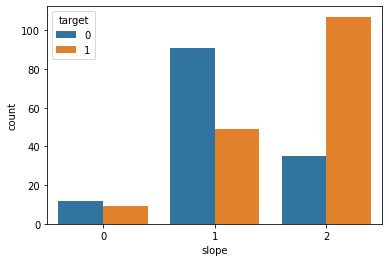

```python
# slope   : the slopw of the peack excercise ST segment
#       -- Value 0: upsloping
#       -- Value 1: flat
#       -- Value 2: downsloping
sns.countplot(x='slope',hue='target',data=heartdata)
```

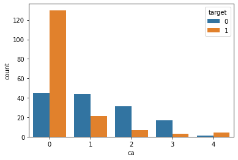

```python
# ca  : number of major vessels colored by flouroscopy (value : 0-4)
sns.countplot(x='ca',hue='target',data=heartdata)
```

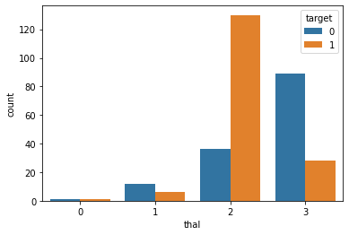

```python
sns.countplot(x='thal',hue='target',data=heartdata)
```

1. Study the occurrence of CVD across different ages. (Bi-variate analysis)

```python
# check the range of age in the dataset
print("min age:",min(heartdata.age))
print("min age:",max(heartdata.age))
```

```
min age: 29
min age: 77
```

```python
# now devide the age feature into 3 parts
# Young= 29-40
# Middle= 40-55
# elder= >55

Young = heartdata[(heartdata.age>=29)&(heartdata.age<40)]
Middle = heartdata[(heartdata.age>=40)&(heartdata.age<55)]
Elder = heartdata[(heartdata.age>55)]
```

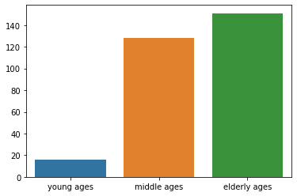

```python
sns.barplot(x=['young ages','middle ages','elderly ages'],y=[len(Young),len(Middle),len(Elder)])
```

1. Can we detect heart attack based on anomalies in resting blood pressure of the patient

[output not shown]

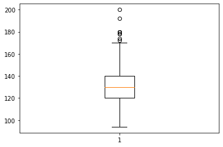

```python
plt.boxplot(heartdata.trestbps)
```

```python
heartdata.trestbps.describe()
```

```
count    303.000000
mean     131.623762
std       17.538143
min       94.000000
25%      120.000000
50%      130.000000
75%      140.000000
max      200.000000
Name: trestbps, dtype: float64
```

```python
140+20*1.5  # upper limit
```

```
170.0
```

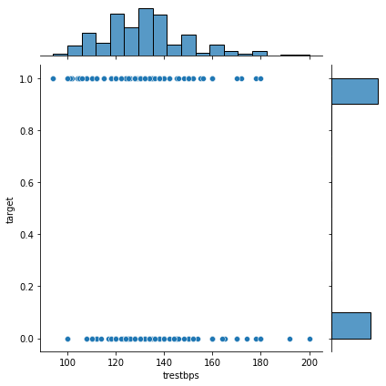

```python
sns.jointplot(heartdata.trestbps,heartdata.target)
```

we can see very low effect of resting blood pressure on heart atatck

```
[Text(0, 0, '207'), Text(0, 0, '96')]
```

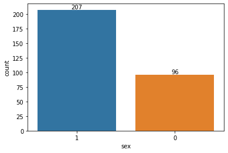

```python
# 7. Study the composition of overall patients w.r.t . gender.
x=sns.countplot(heartdata.sex,order = heartdata.sex.value_counts().index)
values =  heartdata.sex.value_counts(ascending=False).values
x.bar_label(container=x.containers[0], labels=values)
```

Male = 207 Female = 96  
We can see the male patient are more than female patient.

```python
heartdata.chol.corr(heartdata.target)
```

```
-0.08523910513756904
```

we can see there is slight negative correlation/no correlation between cholesterol and cvd.

```python
# 9. What can be concluded about the relationship between peak exercising and occurrence of heart attack?
heartdata.oldpeak.corr(heartdata.target)
```

```
-0.4306960016873684
```

Negative correlation between peak exercising and occurrence of heart attack.

```python
# 10. Is thalassemia a major cause of CVD? How are the other factors determining the occurrence of CVD?
heartdata.thal.corr(heartdata.target)  # Negatively correalted
```

```
-0.3440292680383098
```

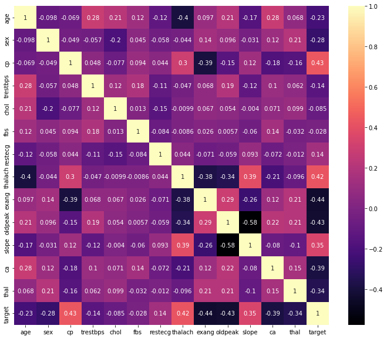

```python
#  other factors determining the occurrence of CVD
plt.figure(figsize=(12,10))
sns.heatmap(heartdata.corr(),annot=True,cmap="magma")
```

We can see there is a positive realtion beween target and cp(chest pain), thalach(Max heart rate), slope, restecg and negative relation between target and exang (exercise induced angina), oldpeak, ca,thal

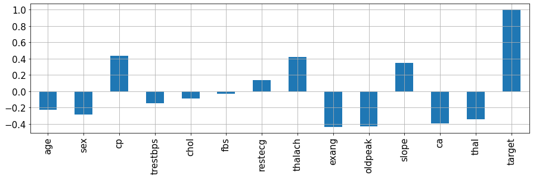

```python
# Another way to see/represent the correlation between target and features
heartdata.corrwith(heartdata.target).plot.bar (figsize=(15,4),fontsize=15,grid=2)
```

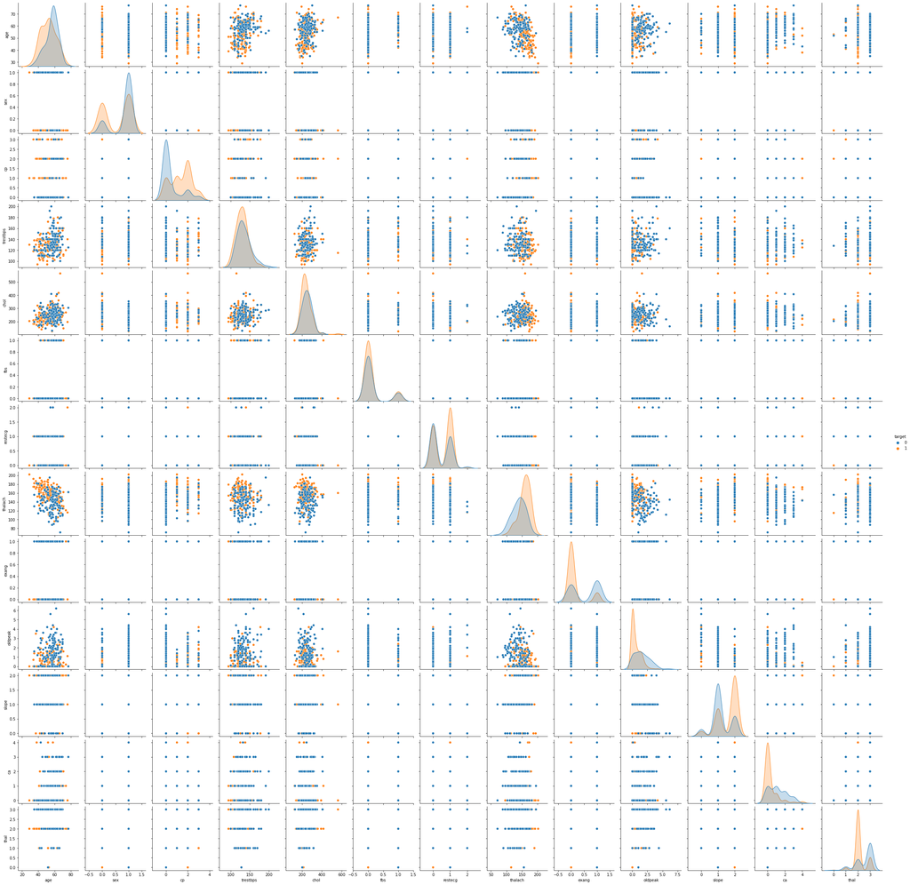

```python
# 11. Use a pair plot to understand the relationship between all the given variables.
sns.pairplot(data=heartdata,hue="target")
```

1. Perform logistic regression, predict the outcome for test data, and validate the results by using the confusion matrix.

```python
# creating a copy on original dataset to perform modelling
heart=heartdata.copy()
heart.head()
```

|  | age | sex | cp | trestbps | chol | fbs | restecg | thalach | exang | oldpeak | slope | ca | thal | target |
| --- | --- | --- | --- | --- | --- | --- | --- | --- | --- | --- | --- | --- | --- | --- |
| 0 | 63 | 1 | 3 | 145 | 233 | 1 | 0 | 150 | 0 | 2.3 | 0 | 0 | 1 | 1 |
| 1 | 37 | 1 | 2 | 130 | 250 | 0 | 1 | 187 | 0 | 3.5 | 0 | 0 | 2 | 1 |
| 2 | 41 | 0 | 1 | 130 | 204 | 0 | 0 | 172 | 0 | 1.4 | 2 | 0 | 2 | 1 |
| 3 | 56 | 1 | 1 | 120 | 236 | 0 | 1 | 178 | 0 | 0.8 | 2 | 0 | 2 | 1 |
| 4 | 57 | 0 | 0 | 120 | 354 | 0 | 1 | 163 | 1 | 0.6 | 2 | 0 | 2 | 1 |

```python
# Spliting the features and Target
x=heart.drop(columns='target',axis=1)
y=heart['target']
```

```python
x.head(2)
```

|  | age | sex | cp | trestbps | chol | fbs | restecg | thalach | exang | oldpeak | slope | ca | thal |
| --- | --- | --- | --- | --- | --- | --- | --- | --- | --- | --- | --- | --- | --- |
| 0 | 63 | 1 | 3 | 145 | 233 | 1 | 0 | 150 | 0 | 2.3 | 0 | 0 | 1 |
| 1 | 37 | 1 | 2 | 130 | 250 | 0 | 1 | 187 | 0 | 3.5 | 0 | 0 | 2 |

```python
y.head(2)
```

```
0    1
1    1
Name: target, dtype: int64
```

```python
# splitting the data into train and test
from sklearn.model_selection import train_test_split
x_train, x_test, y_train, y_test = train_test_split(x, y, test_size=0.2, random_state=2)
```

```python
print("x_train shape is ", x_train.shape)
print("y_train shape is ", y_train.shape)
print("x_test shape is ", x_test.shape)
print("y_test shape is ", y_test.shape)
```

```
x_train shape is  (242, 13)
y_train shape is  (242,)
x_test shape is  (61, 13)
y_test shape is  (61,)
```

```python
# Applying logistic regression
from sklearn.linear_model import LogisticRegression
lr= LogisticRegression()
model = lr.fit(x_train, y_train)    # Train the model with training set of data
```

```python
model
```

```
LogisticRegression()
```

```python
# Accuracy on training data
from sklearn.metrics import accuracy_score
x_train_prediction = lr.predict(x_train)
training_data_accuracy = accuracy_score(x_train_prediction, y_train)
```

```python
print('Accuracy on Training data : ', training_data_accuracy)
```

```
Accuracy on Training data :  0.8305785123966942
```

```python
# Accuracy on test data
x_test_prediction = lr.predict(x_test)
test_data_accuracy = accuracy_score(x_test_prediction, y_test)
print('Accuracy on Test data : ', test_data_accuracy)
```

```
Accuracy on Test data :  0.9016393442622951
```

```python
# validate the results by using the confusion matrix
from sklearn.metrics import confusion_matrix
cm=confusion_matrix(y_test,x_test_prediction)
```

```python
cm
```

```
array([[26,  6],
       [ 0, 29]], dtype=int64)
```

```python
TP=cm[0][0]
TN=cm[1][1]
FN=cm[1][0]
FP=cm[0][1]
print("Testing Accuracy:", (TP+TN)/(TP+TN+FP+FN))
```

```
Testing Accuracy: 0.9016393442622951
```

Finally, the model accuracy obtained from confusion matrix is 90%.